# Chapter 5: Dimensionality reduction techniques

## PCA on the non-standardized dataset

I consider the *non standardized* dataset and perform the Principal Component Analysis (PCA). The summary of the PCA, together with a biplot, follows.

```
## Importance of components%s:
##                              PC1      PC2   PC3   PC4   PC5   PC6    PC7
## Standard deviation     1.854e+04 185.5219 25.19 11.45 3.766 1.566 0.1912
## Proportion of Variance 9.999e-01   0.0001  0.00  0.00 0.000 0.000 0.0000
## Cumulative Proportion  9.999e-01   1.0000  1.00  1.00 1.000 1.000 1.0000
##                           PC8
## Standard deviation     0.1591
## Proportion of Variance 0.0000
## Cumulative Proportion  1.0000
```

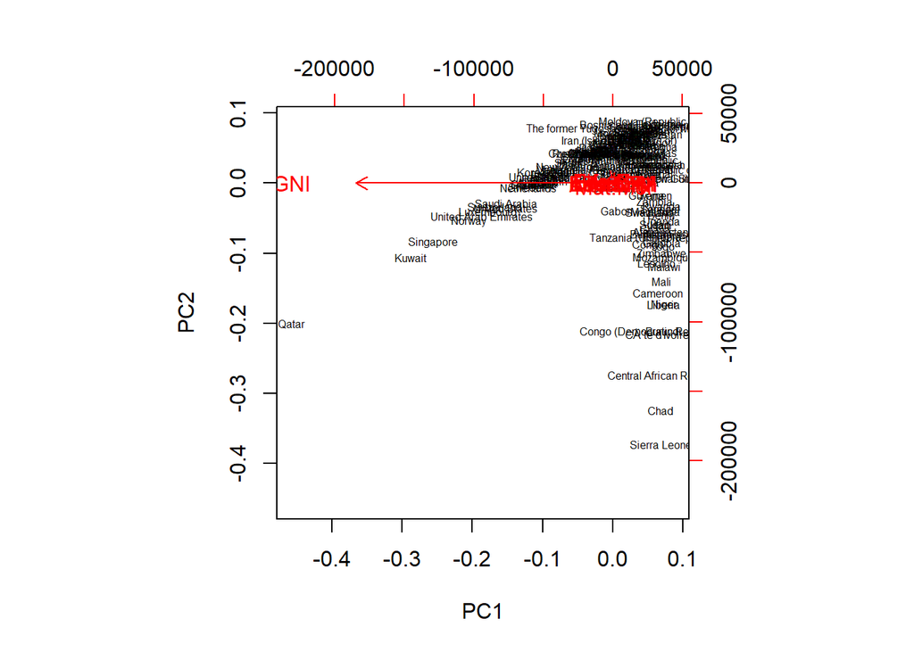

Figure 1: Biplot of PC on non-standardized ‘human’: the PCA is not useful to reduce the components because the variance of the GNI dominates by some orders of magnitude.

It is evident that almost all the variance is captured by the principal component, which is aligned with the variable GNI. This is because the variance of the variable GNI is itself on a completely different scale compared to the other variables. Indeed, notice the large difference between standard deviations of the principal components:

```
## [1] 1.854416e+04 1.855219e+02 2.518701e+01 1.145441e+01 3.766241e+00
## [6] 1.565912e+00 1.912052e-01 1.591112e-01
```

## PCA on the standardized dataset

I now consider the standardized dataset.

```
##     Edu2.FM           Labo.FM           Edu.Exp           Life.Exp
##  Min.   :-2.8189   Min.   :-2.6247   Min.   :-2.7378   Min.   :-2.7188
##  1st Qu.:-0.5233   1st Qu.:-0.5484   1st Qu.:-0.6782   1st Qu.:-0.6425
##  Median : 0.3503   Median : 0.2316   Median : 0.1140   Median : 0.3056
##  Mean   : 0.0000   Mean   : 0.0000   Mean   : 0.0000   Mean   : 0.0000
##  3rd Qu.: 0.5958   3rd Qu.: 0.7350   3rd Qu.: 0.7126   3rd Qu.: 0.6717
##  Max.   : 2.6646   Max.   : 1.6632   Max.   : 2.4730   Max.   : 1.4218
##       GNI             Mat.Mor          Ado.Birth          Parli.F
##  Min.   :-0.9193   Min.   :-0.6992   Min.   :-1.1325   Min.   :-1.8203
##  1st Qu.:-0.7243   1st Qu.:-0.6496   1st Qu.:-0.8394   1st Qu.:-0.7409
##  Median :-0.3013   Median :-0.4726   Median :-0.3298   Median :-0.1403
##  Mean   : 0.0000   Mean   : 0.0000   Mean   : 0.0000   Mean   : 0.0000
##  3rd Qu.: 0.3712   3rd Qu.: 0.1932   3rd Qu.: 0.6030   3rd Qu.: 0.6127
##  Max.   : 5.6890   Max.   : 4.4899   Max.   : 3.8344   Max.   : 3.1850
```

Next, I perform the PCA and present a biplot for the standardized dataset.

```
## Importance of components%s:
##                           PC1    PC2     PC3     PC4     PC5     PC6
## Standard deviation     2.0708 1.1397 0.87505 0.77886 0.66196 0.53631
## Proportion of Variance 0.5361 0.1624 0.09571 0.07583 0.05477 0.03595
## Cumulative Proportion  0.5361 0.6984 0.79413 0.86996 0.92473 0.96069
##                            PC7     PC8
## Standard deviation     0.45900 0.32224
## Proportion of Variance 0.02634 0.01298
## Cumulative Proportion  0.98702 1.00000
```

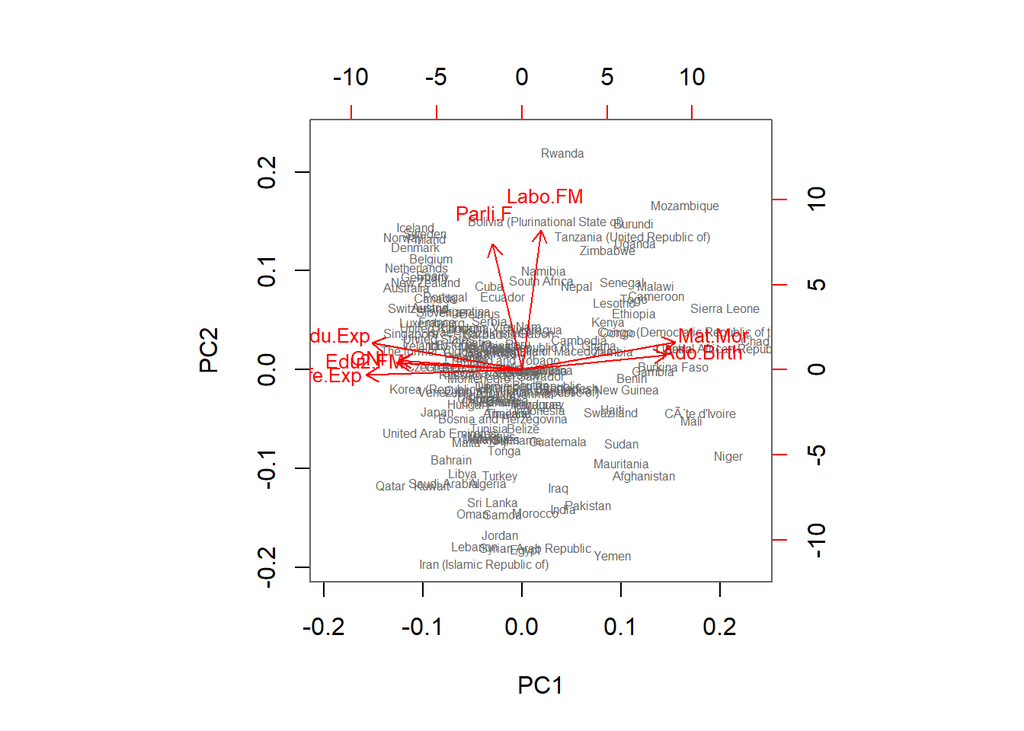

Figure 2: Biplot of PC on standardized ‘human’: most of the variables are correlated with each other and with the first principal component (capturing more than 50% of the variation), while the number of women in parliament and the ratio between women and men in the labor force are strongly correlated with each other and with PC2 (capturing almost another 20% of the variation).

After standardization, the variance of different variables can be compared and their contribution to the total variance are of the same order of magnitude. The two first PC capture almost 70% of the cumulative variance.

## Interpretation of PCA

From the biplot, we observe that most of the variables are aligned with one of the two axis, so all the variables are higly correlated with either PC1 or PC2. The two variables ‘labo.FM’ and ‘Parli’ are strongly correlated with the PC2, while all the other variables are correlated with the PC1. Since the two PC captures almost 70% of the variance, they may be sufficient to get sgnificant insight on the data.

## Multiple Correspondence Analysis (MCA)

Consider the ‘tea’ dataset from the library ‘FactoMineR’.

```r
library(FactoMineR)
data("tea")
dim(tea)
```

```
## [1] 300  36
```

```r
str(tea)
```

```
## 'data.frame':    300 obs. of  36 variables:
##  $ breakfast       : Factor w/ 2 levels "breakfast","Not.breakfast": 1 1 2 2 1 2 1 2 1 1 ...
##  $ tea.time        : Factor w/ 2 levels "Not.tea time",..: 1 1 2 1 1 1 2 2 2 1 ...
##  $ evening         : Factor w/ 2 levels "evening","Not.evening": 2 2 1 2 1 2 2 1 2 1 ...
##  $ lunch           : Factor w/ 2 levels "lunch","Not.lunch": 2 2 2 2 2 2 2 2 2 2 ...
##  $ dinner          : Factor w/ 2 levels "dinner","Not.dinner": 2 2 1 1 2 1 2 2 2 2 ...
##  $ always          : Factor w/ 2 levels "always","Not.always": 2 2 2 2 1 2 2 2 2 2 ...
##  $ home            : Factor w/ 2 levels "home","Not.home": 1 1 1 1 1 1 1 1 1 1 ...
##  $ work            : Factor w/ 2 levels "Not.work","work": 1 1 2 1 1 1 1 1 1 1 ...
##  $ tearoom         : Factor w/ 2 levels "Not.tearoom",..: 1 1 1 1 1 1 1 1 1 2 ...
##  $ friends         : Factor w/ 2 levels "friends","Not.friends": 2 2 1 2 2 2 1 2 2 2 ...
##  $ resto           : Factor w/ 2 levels "Not.resto","resto": 1 1 2 1 1 1 1 1 1 1 ...
##  $ pub             : Factor w/ 2 levels "Not.pub","pub": 1 1 1 1 1 1 1 1 1 1 ...
##  $ Tea             : Factor w/ 3 levels "black","Earl Grey",..: 1 1 2 2 2 2 2 1 2 1 ...
##  $ How             : Factor w/ 4 levels "alone","lemon",..: 1 3 1 1 1 1 1 3 3 1 ...
```

[output cut: 22 more lines]

The dataset contains 300 observations of 36 variables regarding tea consumption.

For the following analysis, I choose only a limited subset of variables to simplify the analysis. I consider only the variables ‘frequency’, ‘How’, ‘Sport’, ‘effect.on.health’, ‘sex’, ‘home’, ‘exciting’, ‘relaxing’.

```
##        frequency      How                Sport
##  1/day      : 95   alone:195   Not.sportsman:121
##  1 to 2/week: 44   lemon: 33   sportsman    :179
##  +2/day     :127   milk : 63
##  3 to 6/week: 34   other:  9
##             effect.on.health sex           home            exciting
##  effect on health   : 66     F:178   home    :291   exciting   :116
##  No.effect on health:234     M:122   Not.home:  9   No.exciting:184
##
##
##         relaxing
##  No.relaxing:113
##  relaxing   :187
##
##
```

I perform the MCA analysis on the reduced dataset:

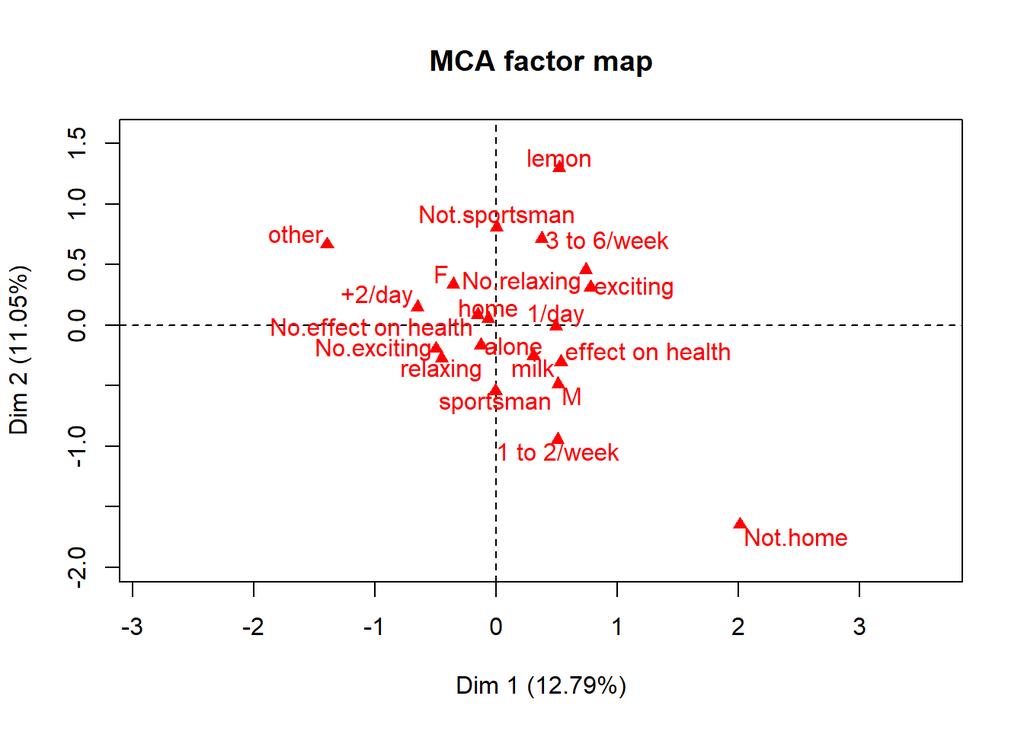

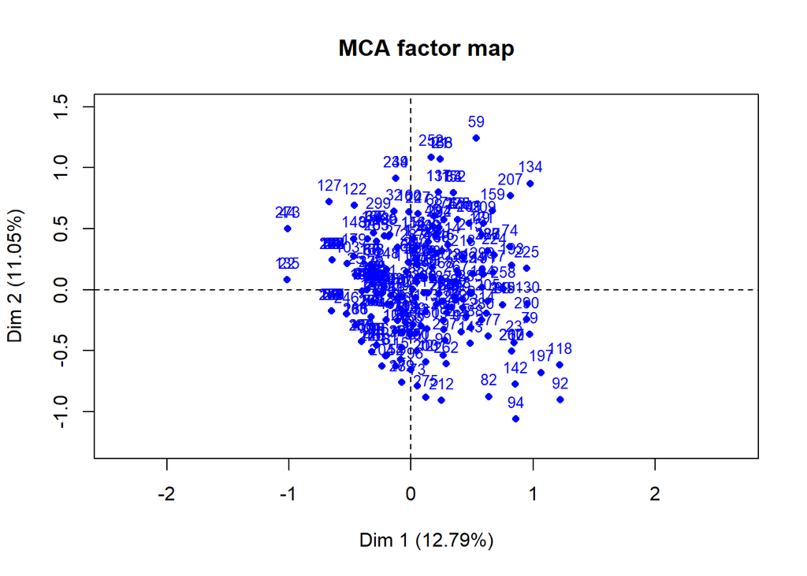

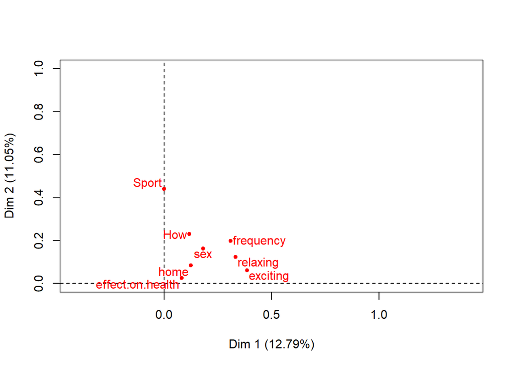

```
##
## Call:
## MCA(X = tea_red, graph = TRUE)
##
##
## Eigenvalues
##                        Dim.1   Dim.2   Dim.3   Dim.4   Dim.5   Dim.6
## Variance               0.192   0.166   0.149   0.138   0.134   0.127
## % of var.             12.786  11.047   9.945   9.172   8.940   8.480
## Cumulative % of var.  12.786  23.833  33.778  42.949  51.889  60.370
##                        Dim.7   Dim.8   Dim.9  Dim.10  Dim.11  Dim.12
## Variance               0.121   0.116   0.100   0.094   0.087   0.077
## % of var.              8.095   7.725   6.654   6.275   5.777   5.104
## Cumulative % of var.  68.465  76.190  82.844  89.119  94.896 100.000
##
## Individuals (the 10 first)
##                  Dim.1    ctr   cos2    Dim.2    ctr   cos2    Dim.3
## 1             |  0.261  0.119  0.074 | -0.251  0.127  0.068 | -0.035
## 2             |  0.502  0.438  0.186 |  0.129  0.034  0.012 | -0.444
## 3             | -0.652  0.738  0.706 | -0.174  0.061  0.050 |  0.180
## 4             | -0.076  0.010  0.006 | -0.059  0.007  0.004 | -0.075
## 5             | -0.405  0.284  0.234 | -0.426  0.365  0.260 |  0.066
## 6             | -0.078  0.011  0.008 | -0.474  0.452  0.282 | -0.042
## 7             | -0.112  0.022  0.008 | -0.253  0.128  0.042 |  0.262
## 8             | -0.198  0.068  0.025 | -0.537  0.579  0.184 | -0.200
## 9             | -0.281  0.137  0.072 | -0.453  0.413  0.187 | -0.524
## 10            | -0.402  0.281  0.202 | -0.010  0.000  0.000 |  0.033
##                  ctr   cos2
## 1              0.003  0.001 |
## 2              0.440  0.145 |
## 3              0.073  0.054 |
## 4              0.012  0.006 |
## 5              0.010  0.006 |
## 6              0.004  0.002 |
## 7              0.153  0.045 |
## 8              0.089  0.026 |
## 9              0.614  0.249 |
## 10             0.002  0.001 |
##
## Categories (the 10 first)
```

[output cut: 18 more lines]

```
## milk           -2.285 |  -1.415  35.224   0.532 -12.613 |
## other           2.023 |  -0.078   0.015   0.000  -0.238 |
## Not.sportsman  11.479 |  -0.061   0.125   0.003  -0.865 |
## sportsman     -11.479 |   0.041   0.085   0.003   0.865 |
##
## Categorical variables (eta2)
##                    Dim.1 Dim.2 Dim.3
## frequency        | 0.310 0.198 0.134 |
## How              | 0.118 0.230 0.539 |
## Sport            | 0.000 0.441 0.003 |
## effect.on.health | 0.081 0.026 0.156 |
## sex              | 0.181 0.163 0.030 |
## home             | 0.125 0.084 0.321 |
## exciting         | 0.386 0.061 0.010 |
## relaxing         | 0.332 0.124 0.000 |
```